# **Problem Statement**

## Business Context

A sales forecast is a prediction of future sales revenue based on historical data, industry trends, and the status of the current sales pipeline. Businesses use the sales forecast to estimate weekly, monthly, quarterly, and annual sales totals. A company needs to make an accurate sales forecast as it adds value across an organization and helps the different verticals to chalk out their future course of action.

Forecasting helps an organization plan its sales operations by region and provides valuable insights to the supply chain team regarding the procurement of goods and materials. An accurate sales forecast process has many benefits which include improved decision-making about the future and reduction of sales pipeline and forecast risks. Moreover, it helps to reduce the time spent in planning territory coverage and establish benchmarks that can be used to assess trends in the future.

## Objective

SuperKart is a retail chain operating supermarkets and food marts across various tier cities, offering a wide range of products. To optimize its inventory management and make informed decisions around regional sales strategies, SuperKart wants to accurately forecast the sales revenue of its outlets for the upcoming quarter.

To operationalize these insights at scale, the company has partnered with a data science firm—not just to build a predictive model based on historical sales data, but to develop and deploy a robust forecasting solution that can be integrated into SuperKart’s decision-making systems and used across its network of stores.

## Data Description

The data contains the different attributes of the various products and stores.The detailed data dictionary is given below.

- **Product_Id** - unique identifier of each product, each identifier having two letters at the beginning followed by a number.
- **Product_Weight** - weight of each product
- **Product_Sugar_Content** - sugar content of each product like low sugar, regular and no sugar
- **Product_Allocated_Area** - ratio of the allocated display area of each product to the total display area of all the products in a store
- **Product_Type** - broad category for each product like meat, snack foods, hard drinks, dairy, canned, soft drinks, health and hygiene, baking goods, bread, breakfast, frozen foods, fruits and vegetables, household, seafood, starchy foods, others
- **Product_MRP** - maximum retail price of each product
- **Store_Id** - unique identifier of each store
- **Store_Establishment_Year** - year in which the store was established
- **Store_Size** - size of the store depending on sq. feet like high, medium and low
- **Store_Location_City_Type** - type of city in which the store is located like Tier 1, Tier 2 and Tier 3. Tier 1 consists of cities where the standard of living is comparatively higher than its Tier 2 and Tier 3 counterparts.
- **Store_Type** - type of store depending on the products that are being sold there like Departmental Store, Supermarket Type 1, Supermarket Type 2 and Food Mart
- **Product_Store_Sales_Total** - total revenue generated by the sale of that particular product in that particular store

# **Installing and Importing the necessary libraries**

```python
#Installing the libraries with the specified versions
!pip install numpy==2.0.2 pandas==2.2.2 scikit-learn==1.6.1 matplotlib==3.10.0 seaborn==0.13.2 joblib==1.4.2 xgboost==2.1.4 requests==2.32.3 huggingface_hub==0.30.1 -q
```

[output not shown]

**Note:**

- After running the above cell, kindly restart the notebook kernel (for Jupyter Notebook) or runtime (for Google Colab) and run all cells sequentially from the next cell.
- On executing the above line of code, you might see a warning regarding package dependencies. This error message can be ignored as the above code ensures that all necessary libraries and their dependencies are maintained to successfully execute the code in this notebook.

```python
import warnings
warnings.filterwarnings("ignore")

# Libraries to help with reading and manipulating data
import numpy as np
import pandas as pd
from scipy.stats import randint

# For splitting the dataset
from sklearn.model_selection import train_test_split

# Libaries to help with data visualization
import matplotlib.pyplot as plt
import seaborn as sns

# Removes the limit for the number of displayed columns
pd.set_option("display.max_columns", None)
# Sets the limit for the number of displayed rows
pd.set_option("display.max_rows", 100)


# Libraries different ensemble classifiers
from sklearn.ensemble import (
    BaggingRegressor,
    RandomForestRegressor,
    AdaBoostRegressor,
    GradientBoostingRegressor,
)
from xgboost import XGBRegressor
from sklearn.tree import DecisionTreeRegressor

# Libraries to get different metric scores
from sklearn.metrics import (
    confusion_matrix,
    accuracy_score,
    precision_score,
    recall_score,
    f1_score,
    mean_squared_error,
    mean_absolute_error,
    r2_score,
    mean_absolute_percentage_error
)

# To create the pipeline
from sklearn.compose import make_column_transformer
from sklearn.pipeline import make_pipeline,Pipeline

# To tune different models and standardize
from sklearn.model_selection import GridSearchCV, RandomizedSearchCV
from sklearn.preprocessing import StandardScaler,OneHotEncoder,OrdinalEncoder

# To serialize the model
import joblib

# os related functionalities
import os

# API request
import requests

# for hugging face space authentication to upload files
from huggingface_hub import login, HfApi, create_repo
```

# **Loading the dataset**

```python
# Mounting google drive
from google.colab import drive
drive.mount('/content/drive')
```

```python
# Loading the dataset
path="/content/drive/MyDrive/AIML/M7_Model_Deployment/Project/SuperKart.csv"
data=pd.read_csv(path)

# Making a copy of the data to keep orginal dataset unchanged
df=data.copy()
```

# **Data Overview**

```python
# Shape of the dataset
df.shape
```

```
(8763, 12)
```

- There are 8763 rows and 12 columns

```python
# Observing the first 5 rows of the dataset
df.head(5)
```

|  | Product_Id | Product_Weight | Product_Sugar_Content | Product_Allocated_Area | Product_Type | Product_MRP | Store_Id | Store_Establishment_Year | Store_Size | Store_Location_City_Type | Store_Type | Product_Store_Sales_Total |
| --- | --- | --- | --- | --- | --- | --- | --- | --- | --- | --- | --- | --- |
| 0 | FD6114 | 12.66 | Low Sugar | 0.027 | Frozen Foods | 117.08 | OUT004 | 2009 | Medium | Tier 2 | Supermarket Type2 | 2842.40 |
| 1 | FD7839 | 16.54 | Low Sugar | 0.144 | Dairy | 171.43 | OUT003 | 1999 | Medium | Tier 1 | Departmental Store | 4830.02 |
| 2 | FD5075 | 14.28 | Regular | 0.031 | Canned | 162.08 | OUT001 | 1987 | High | Tier 2 | Supermarket Type1 | 4130.16 |
| 3 | FD8233 | 12.10 | Low Sugar | 0.112 | Baking Goods | 186.31 | OUT001 | 1987 | High | Tier 2 | Supermarket Type1 | 4132.18 |
| 4 | NC1180 | 9.57 | No Sugar | 0.010 | Health and Hygiene | 123.67 | OUT002 | 1998 | Small | Tier 3 | Food Mart | 2279.36 |

```python
# Information of the dataset
df.info()
```

```
<class 'pandas.core.frame.DataFrame'>
RangeIndex: 8763 entries, 0 to 8762
Data columns (total 12 columns):
 #   Column                     Non-Null Count  Dtype
---  ------                     --------------  -----
 0   Product_Id                 8763 non-null   object
 1   Product_Weight             8763 non-null   float64
 2   Product_Sugar_Content      8763 non-null   object
 3   Product_Allocated_Area     8763 non-null   float64
 4   Product_Type               8763 non-null   object
 5   Product_MRP                8763 non-null   float64
 6   Store_Id                   8763 non-null   object
 7   Store_Establishment_Year   8763 non-null   int64
 8   Store_Size                 8763 non-null   object
 9   Store_Location_City_Type   8763 non-null   object
 10  Store_Type                 8763 non-null   object
 11  Product_Store_Sales_Total  8763 non-null   float64
dtypes: float64(4), int64(1), object(7)
memory usage: 821.7+ KB
```

- There are 7 variables of object (string) datatype:
  - Product_Id, Product_Sugar_Content, Product_Type, Store_Id, Store_Size, Store_Location_City_Type, Store_Type
  - Some of these variables (such as Product_Sugar_Content) will be encoded into numerical variables that can be utilized in the training of the machine learning model.
- There are 5 variables of numerical datatype:
  - Product_Weight, Product_Allocated_Area, Product_MRP, Store_Establishment_Year, Product_Store_Sales_Total.

```python
# Statistical description of the dataset
df.describe().T
```

|  | count | mean | std | min | 25% | 50% | 75% | max |
| --- | --- | --- | --- | --- | --- | --- | --- | --- |
| Product_Weight | 8763.0 | 12.653792 | 2.217320 | 4.000 | 11.150 | 12.660 | 14.180 | 22.000 |
| Product_Allocated_Area | 8763.0 | 0.068786 | 0.048204 | 0.004 | 0.031 | 0.056 | 0.096 | 0.298 |
| Product_MRP | 8763.0 | 147.032539 | 30.694110 | 31.000 | 126.160 | 146.740 | 167.585 | 266.000 |
| Store_Establishment_Year | 8763.0 | 2002.032751 | 8.388381 | 1987.000 | 1998.000 | 2009.000 | 2009.000 | 2009.000 |
| Product_Store_Sales_Total | 8763.0 | 3464.003640 | 1065.630494 | 33.000 | 2761.715 | 3452.340 | 4145.165 | 8000.000 |

```python
# Checking for missing values
df.isnull().sum()
```

|  | 0 |
| --- | --- |
| Product_Id | 0 |
| Product_Weight | 0 |
| Product_Sugar_Content | 0 |
| Product_Allocated_Area | 0 |
| Product_Type | 0 |
| Product_MRP | 0 |
| Store_Id | 0 |
| Store_Establishment_Year | 0 |
| Store_Size | 0 |
| Store_Location_City_Type | 0 |
| Store_Type | 0 |
| Product_Store_Sales_Total | 0 |

**dtype:** int64

- There are no missing values.

```python
# Checking for duplicate values
df.duplicated().sum()
```

```
np.int64(0)
```

- There are no duplicate values.

# **Exploratory Data Analysis (EDA)**

## Univariate Analysis

```python
# List of numerical variables
numerical=['Product_Weight','Product_Allocated_Area','Product_MRP','Store_Establishment_Year','Product_Store_Sales_Total']

# List of object (string) variables
categorical=['Product_Sugar_Content','Product_Type','Store_Id','Store_Size','Store_Location_City_Type','Store_Type']
```

- Note that Product_Id is excluded from analysis since each value is unique and will not add any value to EDA and the model.

```python
# Defining a function to loop over each categorical variable and plotting them on a countplot on a grid

def plot_categorical_grid(df, categorical, n_cols=3, figsize=(15, 10)):
    """
    Plots countplots for the given list of categorical variables in a grid.

    Parameters:
    -----------
    df : The dataframe containing the data.
    categorical :List of categorical column names to plot.
    n_cols :  Number of columns in the grid layout (Default: n_cols=3)
    figsize : Size of the entire figure (Defalut: (15,10))
    """
    n_plots = len(categorical)
    n_rows = int(np.ceil(n_plots / n_cols))

    fig, axes = plt.subplots(n_rows, n_cols, figsize=figsize)
    axes = axes.flatten()

    for i, col in enumerate(categorical):
        sns.countplot(data=df, x=col, ax=axes[i], palette='viridis')
        axes[i].set_title(f'Countplot of {col}', fontsize=12)
        axes[i].tick_params(axis='x', rotation=45)

    # Hide any unused subplots
    for j in range(i + 1, len(axes)):
        fig.delaxes(axes[j])

    plt.tight_layout()
    plt.show()
```

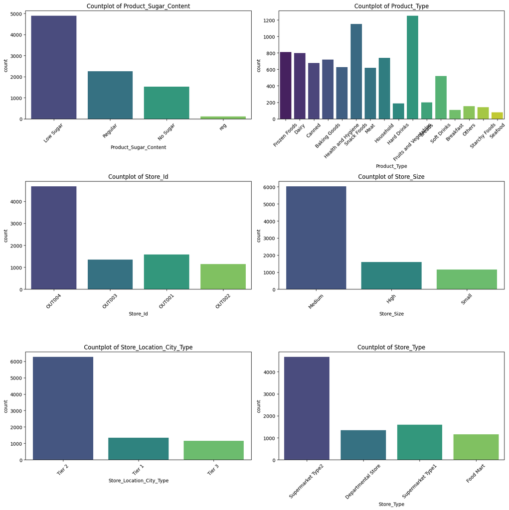

```python
# Plotting the distribution of categorical variables
plot_categorical_grid(df,categorical,n_cols=2, figsize=(15,15))
```

- Observations on categorical variables:
  - Product_Sugar_Content
    - The majority of products have a Low Sugar content, followed by Regular, No Sugar.
    - Note a few products have listed having 'reg' sugar content instead of 'Regular'. This will be dealt with in data preprocessing.
  - Product_Type
    - The most popular product types are 'Fruit and Vegetables' and 'Snack Foods'
    - 'Seafood' and 'Breakfast' are amongst the least popular product types.
  - Store_Id
    - The products are sold from 4 different stores, with the busiest (with the highest count of products being sold) being 'OUT004'.
  - Store_Size
    - The majority of products were sold in stores with a size of 'Medium', followed by 'High' and 'Small'
  - Store_Location_City_Type
    - The majority of products were sold in stores located in 'Tier 2', followed by 'Tier 1' and 'Tier 3'
  - Store_Type
    - The majority of products were sold in stores with the storetype of 'Supermarket Type 2'.

```python
# Defining function to plot numerical variables on histograms and boxplots
def plot_numerical_grid(df, numerical_cols, n_cols=2, figsize=(12, 8)):
    """
    Plots histograms and boxplots for each numerical variable in a grid layout.

    Parameters:
    -----------
    df : The dataframe containing the data.
    numerical_cols : List of numerical column names to plot.
    n_cols : Number of columns in the grid layout (Default: n_cols=2)
    figsize : Overall figure size (Default: (12, 8))
    """
    n_plots = len(numerical_cols) * 2  # Each variable has a histogram and a boxplot
    n_rows = int(np.ceil(n_plots / n_cols))

    fig, axes = plt.subplots(n_rows, n_cols, figsize=figsize)
    axes = axes.flatten()

    plot_idx = 0
    for col in numerical_cols:
        # Histogram
        sns.histplot(data=df, x=col, kde=True, ax=axes[plot_idx], color='steelblue')
        axes[plot_idx].set_title(f'Histogram of {col}', fontsize=12)
        plot_idx += 1

        # Boxplot
        sns.boxplot(data=df, x=col, ax=axes[plot_idx], color='lightcoral')
        axes[plot_idx].set_title(f'Boxplot of {col}', fontsize=12)
        plot_idx += 1

    # Hide any unused axes
    for j in range(plot_idx, len(axes)):
        fig.delaxes(axes[j])

    plt.tight_layout()
    plt.show()
```

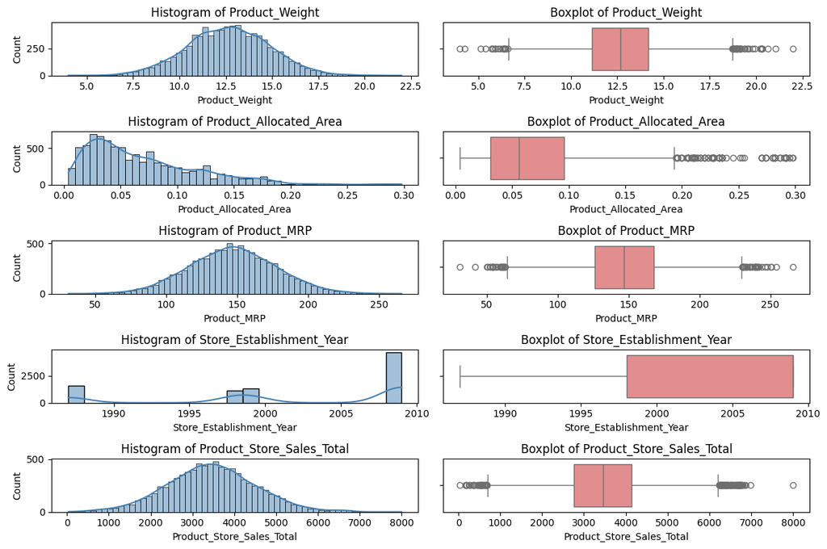

```python
# Plotting histograms and boxplots of numerical variables
plot_numerical_grid(df,numerical,n_cols=2)
```

- Observations on Numerical variables:
  - Product_Weight
    - The weights of the products are symmetrically distributed.
    - There outliers that are relatively light and relatively heavy in comparison the the other products. However these weights appear to be realistic and no need to treat these outliers.
  - Product_Allocated_Area
    - The product allocated area (the ratio of the allocated display area of each product to the total display area of all the products in a store) is right-skewed (positively skewed).
    - Naturally with a skewed distribution, there are outliers. In this case, there are products that have an abnormally high product allocated area in comparison to the rest.
    - However these values appear to be realistic and will not be be treated.
  - Product_MRP
    - The maximum retail prices of each product are symmetrically distributed
    - There outliers that are relatively cheap and relatively expensive in comparison the the other products. However these values appear to be realistic and no need to treat these outliers.
  - Store_Establishment_Year
    - Since there are only 4 stores in this dataset, there are only 4 different establishment years.
    - Most products are sold in the store established in 2009 (OUT004).
  - Product_Store_Sales_Total (target variable)
    - The total revenue generated by the sale of a particular product in its respective store is symmetrically distributed.
    - There appears to be outliers of relatively low and relatively high revenue but they appear to be realistic and no need to treat them.
      - However, there is an extreme outlier that appears unrealistic and should be treated.
        - Since this is the target variable, even one extreme outlier can result in higher error and less model accuracy.

## Bivariate Analysis

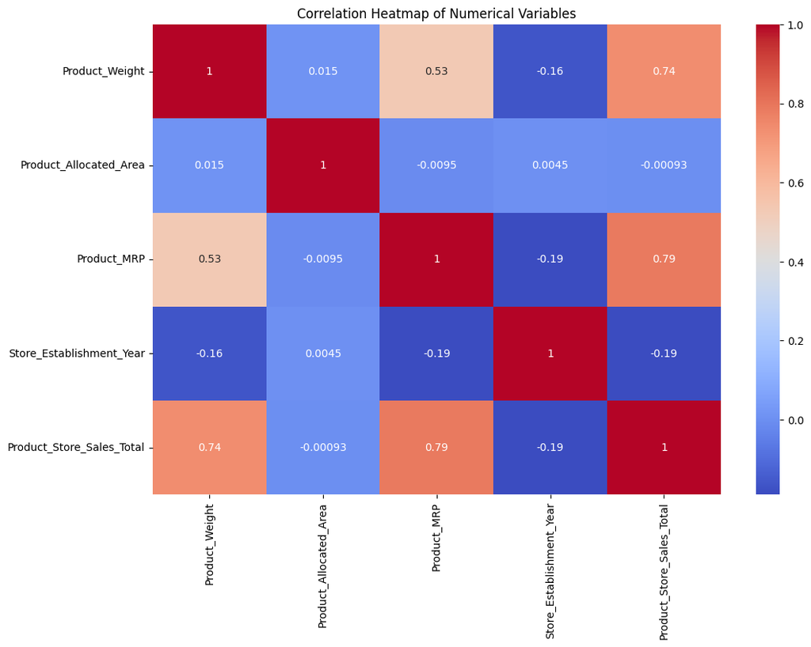

```python
# Creating a heatmap of the correlation matrix of numerical variables
plt.figure(figsize=(12, 8))
sns.heatmap(df[numerical].corr(), annot=True, cmap='coolwarm')
plt.title('Correlation Heatmap of Numerical Variables')
plt.show()
```

- Notable correlations include:
  - Strong positive correlation between Product_Store_Sales_Total and Product_Weight (r=0.74)
    - This indicates that the heavier the product, the more revenue that product generates for its respective store.
  - Strong positive correlation between Product_Store_Sales_Total and Product_MRP (r=0.79)
    - This indicates that the higher the maximum retail prices of each product, the more revenue that product generates for its respective store, which makes sense.
  - Moderate positive correlation between Product_Weight and Product_MRP (r=0.53)
    - This indicates that the heavier the product, the higher the maximum retail prices of each product.

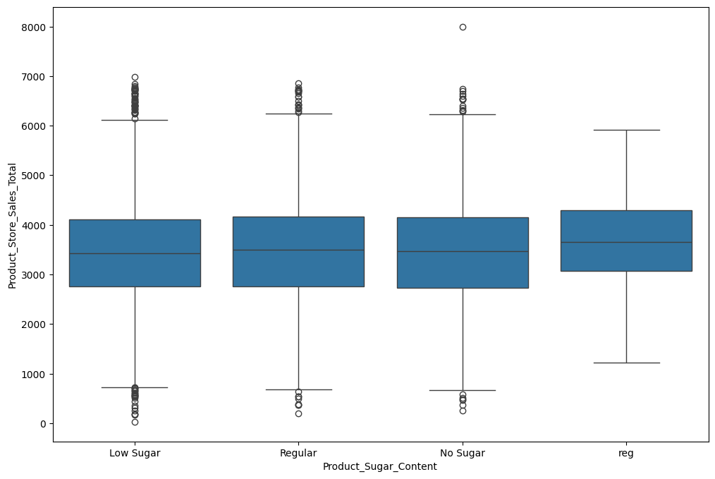

```python
# Distribution of Product_Store_Sales_Total by Product_Sugar_Content using boxplots
plt.figure(figsize=(12, 8))
sns.boxplot(df, x='Product_Sugar_Content', y='Product_Store_Sales_Total')
plt.show()
```

- Revenue does not differ by sugar content of the product.

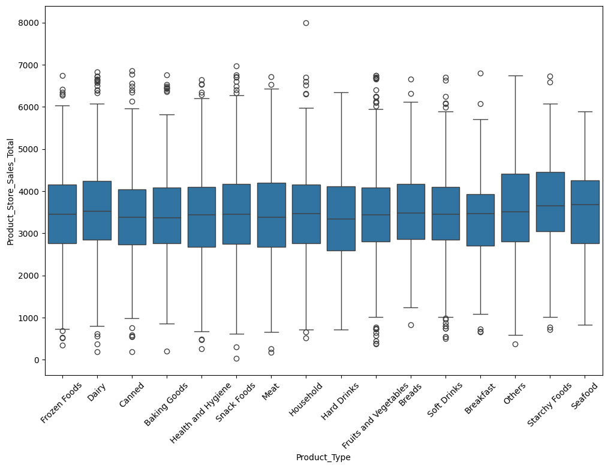

```python
# Distribution of Product_Store_Sales_Total by Product_Type using boxplots
plt.figure(figsize=(12, 8))
sns.boxplot(df, x='Product_Type', y='Product_Store_Sales_Total')
plt.xticks(rotation=45)
plt.show()
```

- The revenue of the product is similar among product type.

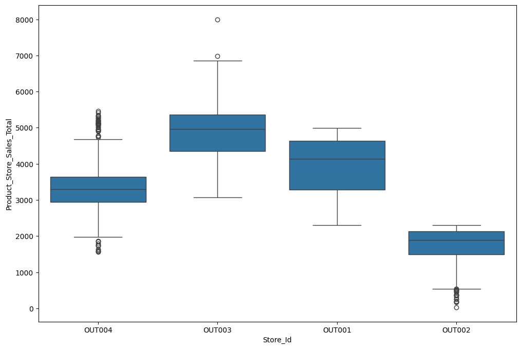

```python
# Distribution of Product_Store_Sales_Total by Store_Id using boxplots
plt.figure(figsize=(12, 8))
sns.boxplot(df, x='Store_Id', y='Product_Store_Sales_Total')
plt.show()
```

- Products sold in the store 'OUT003' have the highest median revenue.
- Products sold in the store 'OUT002' have the lowest median revenue.

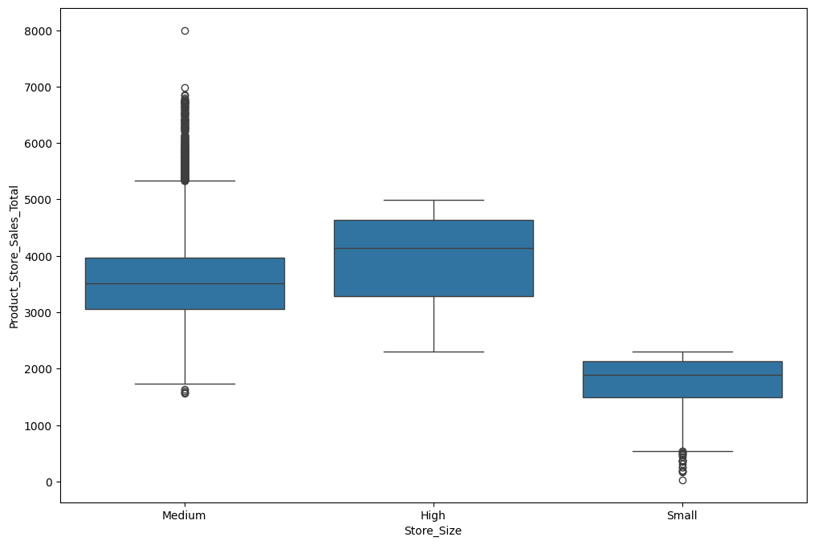

```python
# Distribution of Product_Store_Sales_Total by Store_Size using boxplots
plt.figure(figsize=(12, 8))
sns.boxplot(df, x='Store_Size', y='Product_Store_Sales_Total')
plt.show()
```

- Products sold in stores with a 'High' store size have the highest median revenue.
- Products sold in stores with a 'Small' store size have the lowest median revenue.

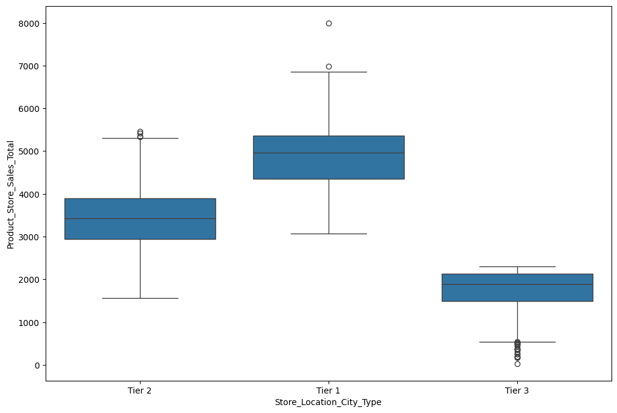

```python
# Distribution of Product_Store_Sales_Total by Store_Location_City_Type using boxplots
plt.figure(figsize=(12, 8))
sns.boxplot(df, x='Store_Location_City_Type', y='Product_Store_Sales_Total')
plt.show()
```

- Products sold in stores of 'Tier 1' city type have the highest median revenue.
- Products sold in stores of 'Tier 3' city type have the lowest median revenue.

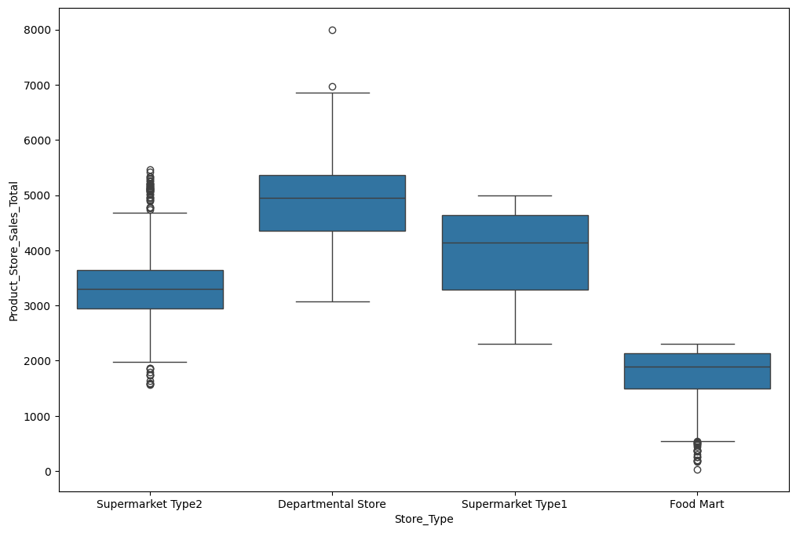

```python
# Distribution of Product_Store_Sales_Total by Store_Type using boxplots
plt.figure(figsize=(12, 8))
sns.boxplot(df, x='Store_Type', y='Product_Store_Sales_Total')
plt.show()
```

- Products sold in Departmental Stores have the highest median revenue.
- Products sold in Food Marts have the lowest median revenue.

# **Data Preprocessing**

Preprocessing logic:

- Preprocessing steps included in pipeline:
  - Standardization scaling, label encoding and one-hot encoding.
  - This will enable new input data from the end user to go through the same preprocessing steps and be prepared for model prediction.
- Preprocessing steps excluded in pipeline:
  - Removal of the single outlier value of the target variable (Product_Store_Sales_Total) from the dataset for one-time cleaning.
  - Standardization of Product_Sugar_Content by replacing the values of 'reg' with 'Regular'
- Selecting predictive features (X) and target variable (y)
  - Product_Store_Sales_Total is the target variable
  - Rest of the features will be included for prediction except for:
    - Product_Id as each value is unique and adds no predictive value.
    - Store_Id since store-level features (establishment year, size, city location and type) are fixed for each Store_Id
      - In the frontend of deployment, the end user will input the Store_Id, and the store's characteristics will be mapped internally which will then be passed on for inference.

```python
# Removing the extreme outlier of 'Product_Store_Sales_Total'
df = df[df['Product_Store_Sales_Total'] != 8000].reset_index(drop=True)
```

```python
# Replacing the values of 'reg' with 'Regular' in Product_Sugar_Content
df['Product_Sugar_Content'] = df['Product_Sugar_Content'].replace('reg', 'Regular')
```

```python
# Separating predictive features (X) and target variable (y)
X = df.drop(columns=['Product_Id','Store_Id','Product_Store_Sales_Total'])
y = df['Product_Store_Sales_Total']

# Splitting the data into train and test sets
X_train, X_test, y_train, y_test = train_test_split(X, y, test_size=0.2, random_state=42)
```

```python
# Numerical predictive features
numerical_features=['Product_Weight','Product_Allocated_Area','Product_MRP','Store_Establishment_Year']
# Separate categorical features by encoding type
ordinal_features = ['Product_Sugar_Content','Store_Size','Store_Location_City_Type']
nominal_features = ['Product_Type', 'Store_Type']

# Define the mappings for the ordinal encoder
ordinal_mappings = [
    ['No Sugar','Low Sugar', 'Regular'], # Product_Sugar_Content
    ['Small','Medium', 'High'],          # Store_Size
    ['Tier 3', 'Tier 2', 'Tier 1']       # Store_Location_City_Type
]

# Creating a preprocessing pipeline
preprocessor = make_column_transformer(
    (StandardScaler(), numerical_features),
    (OrdinalEncoder(categories=ordinal_mappings), ordinal_features),
    (OneHotEncoder(handle_unknown='ignore'), nominal_features)
)
```

# **Model Building**

## Define functions for Model Evaluation

```python
# function to compute adjusted R-squared
def adj_r2_score(predictors, targets, predictions):
    r2 = r2_score(targets, predictions)
    n = predictors.shape[0]
    k = predictors.shape[1]
    return 1 - ((1 - r2) * (n - 1) / (n - k - 1))


# function to compute different metrics to check performance of a regression model
def model_performance_regression(model, predictors, target):
    """
    Function to compute different metrics to check regression model performance

    model: regressor
    predictors: independent variables
    target: dependent variable
    """

    # predicting using the independent variables
    pred = model.predict(predictors)

    r2 = r2_score(target, pred)  # to compute R-squared
    adjr2 = adj_r2_score(predictors, target, pred)  # to compute adjusted R-squared
    rmse = np.sqrt(mean_squared_error(target, pred))  # to compute RMSE
    mae = mean_absolute_error(target, pred)  # to compute MAE
    mape = mean_absolute_percentage_error(target, pred)  # to compute MAPE

    # creating a dataframe of metrics
    df_perf = pd.DataFrame(
        {
            "RMSE": rmse,
            "MAE": mae,
            "R-squared": r2,
            "Adj. R-squared": adjr2,
            "MAPE": mape,
        },
        index=[0],
    )

    return df_perf
```

The ML models to be built can be any two out of the following:

1. Decision Tree
2. Bagging
3. Random Forest
4. AdaBoost
5. Gradient Boosting
6. XGBoost

## Model 1: Random Forest Regressor (Default)

```python
# Creating RF pipeline with preprocessor
model1_pipeline=make_pipeline(preprocessor,
                      RandomForestRegressor(random_state=42)
                      )

# Fitting the model on train data
model1_pipeline.fit(X_train,y_train)
```

```
Pipeline(steps=[('columntransformer',
                 ColumnTransformer(transformers=[('standardscaler',
                                                  StandardScaler(),
                                                  ['Product_Weight',
                                                   'Product_Allocated_Area',
                                                   'Product_MRP',
                                                   'Store_Establishment_Year']),
                                                 ('ordinalencoder',
                                                  OrdinalEncoder(categories=[['No '
                                                                              'Sugar',
                                                                              'Low '
                                                                              'Sugar',
                                                                              'Regular'],
                                                                             ['Small',
                                                                              'Medium',
                                                                              'High'],
                                                                             ['Tier '
                                                                              '3',
                                                                              'Tier '
                                                                              '2',
                                                                              'Tier '
                                                                              '1']]),
                                                  ['Product_Sugar_Content',
                                                   'Store_Size',
                                                   'Store_Location_City_Type']),
                                                 ('onehotencoder',
                                                  OneHotEncoder(handle_unknown='ignore'),
                                                  ['Product_Type',
                                                   'Store_Type'])])),
                ('randomforestregressor',
                 RandomForestRegressor(random_state=42))])
```

```python
# Performance metrics of model 1 on train data
perf_m1_train=model_performance_regression(model1_pipeline,X_train,y_train)
perf_m1_train
```

|  | RMSE | MAE | R-squared | Adj. R-squared | MAPE |
| --- | --- | --- | --- | --- | --- |
| 0 | 107.474893 | 40.736595 | 0.989786 | 0.989773 | 0.01508 |

```python
# Performance metrics of model 1 on test data
perf_m1_test=model_performance_regression(model1_pipeline,X_test,y_test)
perf_m1_test
```

|  | RMSE | MAE | R-squared | Adj. R-squared | MAPE |
| --- | --- | --- | --- | --- | --- |
| 0 | 276.672269 | 105.286025 | 0.932946 | 0.932599 | 0.039212 |

Model 1 (Random Forest Regressor - Default) Observations:

- Performance
  - Very high performance on the train set (r2=0.9898)
    - i.e the model explained around 98.98% of the variance of the target variable in the train set
  - High performance on the test set (r2=.9329)
    - i.e the model explained around 93.29% of the variance of the target variable in the test set
- Generalization
  - This model has decent generalization as the performance on the train and test are similar.
  - However the model is slightly overfitted.

## Model 2: XGBoost Regressor (Default)

```python
# Creating XGBosst pipeline with preprocessor
model2_pipeline=make_pipeline(preprocessor,
                      XGBRegressor(random_state=42)
                      )

# Fitting the model on train data
model2_pipeline.fit(X_train,y_train)
```

```
Pipeline(steps=[('columntransformer',
                 ColumnTransformer(transformers=[('standardscaler',
                                                  StandardScaler(),
                                                  ['Product_Weight',
                                                   'Product_Allocated_Area',
                                                   'Product_MRP',
                                                   'Store_Establishment_Year']),
                                                 ('ordinalencoder',
                                                  OrdinalEncoder(categories=[['No '
                                                                              'Sugar',
                                                                              'Low '
                                                                              'Sugar',
                                                                              'Regular'],
                                                                             ['Small',
                                                                              'Medium',
                                                                              'High'],
                                                                             ['Tier '
                                                                              '3',
                                                                              'Tier '
                                                                              '2',
                                                                              'Tier '
                                                                              '1']]),
                                                  ['Product_Sugar_Co...
                              feature_types=None, gamma=None, grow_policy=None,
                              importance_type=None,
                              interaction_constraints=None, learning_rate=None,
                              max_bin=None, max_cat_threshold=None,
                              max_cat_to_onehot=None, max_delta_step=None,
                              max_depth=None, max_leaves=None,
                              min_child_weight=None, missing=nan,
                              monotone_constraints=None, multi_strategy=None,
                              n_estimators=None, n_jobs=None,
                              num_parallel_tree=None, random_state=42, ...))])
```

```python
# Performance metrics of model 2 on train data
perf_m2_train=model_performance_regression(model2_pipeline,X_train,y_train)
perf_m2_train
```

|  | RMSE | MAE | R-squared | Adj. R-squared | MAPE |
| --- | --- | --- | --- | --- | --- |
| 0 | 125.129636 | 60.986255 | 0.986154 | 0.986137 | 0.022101 |

```python
# Performance metrics of model 2 on test data
perf_m2_test=model_performance_regression(model2_pipeline,X_test,y_test)
perf_m2_test
```

|  | RMSE | MAE | R-squared | Adj. R-squared | MAPE |
| --- | --- | --- | --- | --- | --- |
| 0 | 295.145496 | 131.487961 | 0.923692 | 0.923298 | 0.048826 |

Model 2 (XGBoost Regressor - Default) Observations:

- Performance
  - Very high performance on the train set (r2=0.9861)
    - i.e the model explained around 98.61% of the variance of the target variable in the train set
  - High performance on the test set (r2=.9237)
    - i.e the model explained around 92.37% of the variance of the target variable in the test set
- Generalization
  - This model has decent generalization as the performance on the train and test are similar.
  - However the model is slightly overfitted.

# **Model Performance Improvement - Hyperparameter Tuning**

## Model 3: Random Forest Regresseor (Fine-tuned)

```python
# Creating RF pipeline with preprocessor
model3_pipeline=make_pipeline(preprocessor,
                      RandomForestRegressor(random_state=42)
                      )
```

```python
# Establishing hyperparamter grid
param_grid_rf = {
    'randomforestregressor__n_estimators': randint(10, 500),
    'randomforestregressor__max_depth': randint(1, 30),
    'randomforestregressor__min_samples_split': randint(2, 20),
    'randomforestregressor__min_samples_leaf': randint(1, 10)
}
```

```python
# Establishing search object
search = RandomizedSearchCV(
    model3_pipeline,
    param_distributions=param_grid_rf,
    n_iter=30,
    cv=5,
    scoring='r2',
    verbose=2,
    random_state=42,
    n_jobs=-1
)

search.fit(X_train, y_train)
```

```
Fitting 5 folds for each of 30 candidates, totalling 150 fits
```

```
RandomizedSearchCV(cv=5,
                   estimator=Pipeline(steps=[('columntransformer',
                                              ColumnTransformer(transformers=[('standardscaler',
                                                                               StandardScaler(),
                                                                               ['Product_Weight',
                                                                                'Product_Allocated_Area',
                                                                                'Product_MRP',
                                                                                'Store_Establishment_Year']),
                                                                              ('ordinalencoder',
                                                                               OrdinalEncoder(categories=[['No '
                                                                                                           'Sugar',
                                                                                                           'Low '
                                                                                                           'Sugar',
                                                                                                           'Regular'],
                                                                                                          ['Small',
                                                                                                           'Medium',
                                                                                                           'High'],
                                                                                                          ['Tier '
                                                                                                           '3',
                                                                                                           'Tier '
                                                                                                           '...
                                        'randomforestregressor__min_samples_leaf': <scipy.stats._distn_infrastructure.rv_discrete_frozen object at 0x7a08c912b650>,
                                        'randomforestregressor__min_samples_split': <scipy.stats._distn_infrastructure.rv_discrete_frozen object at 0x7a08c912b470>,
                                        'randomforestregressor__n_estimators': <scipy.stats._distn_infrastructure.rv_discrete_frozen object at 0x7a08c92a95e0>},
                   random_state=42, scoring='r2', verbose=2)
```

```python
# Get the full trained pipeline
best_model3_pipeline=search.best_estimator_
```

```python
# Performance metrics of model 3 on train data
perf_m3_train=model_performance_regression(best_model3_pipeline,X_train,y_train)
perf_m3_train
```

|  | RMSE | MAE | R-squared | Adj. R-squared | MAPE |
| --- | --- | --- | --- | --- | --- |
| 0 | 200.192029 | 71.068192 | 0.964561 | 0.964515 | 0.02702 |

```python
# Performance metrics of model 3 on test data
perf_m3_test=model_performance_regression(best_model3_pipeline,X_test,y_test)
perf_m3_test
```

|  | RMSE | MAE | R-squared | Adj. R-squared | MAPE |
| --- | --- | --- | --- | --- | --- |
| 0 | 270.207609 | 102.040698 | 0.936043 | 0.935712 | 0.037844 |

Model 3 (Random Forest Regressor - Fine-tuned) Observations:

- Performance
  - Very high performance on the train set (r2=0.96456)
    - It performed slightly worse than the default Random Forest model (Model 1) on the train set
  - High performance on the test set (r2=.9360)
    - It performed marginally better than the default Random Forest model (Model 1) on the test set
- Generalization
  - This model has good generalization as the performance on the train and test are similar.
    - There is a smaller gap between the train and test performnaces compared to Model 1.
    - The slightly worse performance on the train set indicates that the model is overfitting less to the training data.

## Model 4: XGBoost Regressor (Fine-tuned)

```python
# Creating XGBoost pipeline with preprocessor
model4_pipeline=make_pipeline(preprocessor,
                      XGBRegressor(random_state=42)
                      )
```

```python
# Establishing hyperparamter grid
param_grid_xgb = {
    'xgbregressor__n_estimators': [100, 200, 300, 400],
    'xgbregressor__max_depth': [3, 5, 7, 9],
    'xgbregressor__learning_rate': [0.01, 0.05, 0.1, 0.2],
    'xgbregressor__subsample': [0.6, 0.8, 1.0],
    'xgbregressor__colsample_bytree': [0.6, 0.8, 1.0],
    'xgbregressor__gamma': [0, 0.1, 0.3, 0.5],
    'xgbregressor__min_child_weight': [1, 3, 5, 7],
    'xgbregressor__reg_lambda': [1, 1.5, 2, 3],
    'xgbregressor__reg_alpha': [0, 0.1, 0.3, 0.5]
}
```

```python
#Establishing search object
search_xgb = RandomizedSearchCV(
    model4_pipeline,
    param_distributions=param_grid_xgb,
    n_iter=30,
    cv=5,
    scoring='r2',
    verbose=2,
    random_state=42,
    n_jobs=-1
)

search_xgb.fit(X_train, y_train)
```

```
Fitting 5 folds for each of 30 candidates, totalling 150 fits
```

```
RandomizedSearchCV(cv=5,
                   estimator=Pipeline(steps=[('columntransformer',
                                              ColumnTransformer(transformers=[('standardscaler',
                                                                               StandardScaler(),
                                                                               ['Product_Weight',
                                                                                'Product_Allocated_Area',
                                                                                'Product_MRP',
                                                                                'Store_Establishment_Year']),
                                                                              ('ordinalencoder',
                                                                               OrdinalEncoder(categories=[['No '
                                                                                                           'Sugar',
                                                                                                           'Low '
                                                                                                           'Sugar',
                                                                                                           'Regular'],
                                                                                                          ['Small',
                                                                                                           'Medium',
                                                                                                           'High'],
                                                                                                          ['Tier '
                                                                                                           '3',
                                                                                                           'Tier '
                                                                                                           '...
                                        'xgbregressor__gamma': [0, 0.1, 0.3,
                                                                0.5],
                                        'xgbregressor__learning_rate': [0.01,
                                                                        0.05,
                                                                        0.1,
                                                                        0.2],
                                        'xgbregressor__max_depth': [3, 5, 7, 9],
                                        'xgbregressor__min_child_weight': [1, 3,
                                                                           5,
                                                                           7],
                                        'xgbregressor__n_estimators': [100, 200,
                                                                       300,
                                                                       400],
                                        'xgbregressor__reg_alpha': [0, 0.1, 0.3,
                                                                    0.5],
                                        'xgbregressor__reg_lambda': [1, 1.5, 2,
                                                                     3],
                                        'xgbregressor__subsample': [0.6, 0.8,
                                                                    1.0]},
                   random_state=42, scoring='r2', verbose=2)
```

```python
# Get the full trained pipeline
best_model4_pipeline=search_xgb.best_estimator_
```

```python
# Performance metrics of model 4 on train data
perf_m4_train=model_performance_regression(best_model4_pipeline,X_train,y_train)
perf_m4_train
```

|  | RMSE | MAE | R-squared | Adj. R-squared | MAPE |
| --- | --- | --- | --- | --- | --- |
| 0 | 211.326088 | 83.722967 | 0.960509 | 0.960458 | 0.030888 |

```python
# Performance metrics of model 4 on test data
perf_m4_test=model_performance_regression(best_model4_pipeline,X_test,y_test)
perf_m4_test
```

|  | RMSE | MAE | R-squared | Adj. R-squared | MAPE |
| --- | --- | --- | --- | --- | --- |
| 0 | 271.750758 | 111.647832 | 0.93531 | 0.934976 | 0.041524 |

Model 4 (XGBoost Regressor - Fine-tuned) Observations:

- Performance
  - Very high performance on the train set (r2=0.9605)
    - It performed slightly worse than the default XGBoost model (Model 2) on the train set
  - High performance on the test set (r2=0.9353)
    - It performed slightly better than the default XGBoost model (Model 2) on the test set
- Generalization
  - This model has good generalization as the performance on the train and test are similar.
    - There is a smaller gap between the train and test performnaces compared to the default XGBoost model (Model 2).
    - The slightly worse performance on the train set indicates that the model is overfitting less to the training data.

# **Model Performance Comparison, Final Model Selection, and Serialization**

## Model Performance Comparison

```python
# Compling model performances into a dataframe
model_perf_df=pd.concat([perf_m1_train['R-squared'],perf_m1_test['R-squared'],perf_m2_train['R-squared'],perf_m2_test['R-squared'],perf_m3_train['R-squared'],perf_m3_test['R-squared'],perf_m4_train['R-squared'],perf_m4_test['R-squared']],axis=1)
model_perf_df.columns=['RF (Default) Train','RF (Default) Test','XGBoost (Default) Train','XGBoost (Default) Test','RF (Fine-tuned) Train','RF (Fine-tuned) Test','XGBoost (Fine-tuned) Train','XGBoost (Fine-tuned) Test']
model_perf_df.index = ['R-squared']
model_perf_df.T
```

|  | R-squared |
| --- | --- |
| RF (Default) Train | 0.989786 |
| RF (Default) Test | 0.932946 |
| XGBoost (Default) Train | 0.986154 |
| XGBoost (Default) Test | 0.923692 |
| RF (Fine-tuned) Train | 0.964561 |
| RF (Fine-tuned) Test | 0.936043 |
| XGBoost (Fine-tuned) Train | 0.960509 |
| XGBoost (Fine-tuned) Test | 0.935310 |

## Final Model Selection

Model 3: Fine-tuned Random Forest Regressor

- Performance
  - Model 3 had the highest performance on the test set (r2=0.9360)
    - I.e 93.6% of the variance of the target variable is explained by the model
- Generalization
  - Model 3 is very good at generalization as it has one of the smallest differences in r2 between the train and test sets
- Simplicity
  - Random Forest models are more simple, stable and interpretable than XGBoost models.
  - It is therefore the safer production choice and easier to mainatin in deployment.

```python
# Performance metrics of model 3 on test data
perf_m3_test=model_performance_regression(best_model3_pipeline,X_test,y_test)
perf_m3_test
```

|  | RMSE | MAE | R-squared | Adj. R-squared | MAPE |
| --- | --- | --- | --- | --- | --- |
| 0 | 270.207609 | 102.040698 | 0.936043 | 0.935712 | 0.037844 |

## Serialization

```python
#Creating a folder for storing files needed for backend web app development
os.makedirs("backend_files",exist_ok=True)
```

```python
# Defining the file path to serialize the trained model pipeline
saved_model_path="backend_files/sales_forecast_model_v1.joblib"
# Serializing the model pipeline
joblib.dump(best_model3_pipeline,saved_model_path)
```

[output not shown]

```python
# Loading the serialized model and making predictions on the test set
loaded_model=joblib.load(saved_model_path)
loaded_model.predict(X_test)
```

```
array([3343.04503703, 3660.24042673, 2415.32557517, ..., 4183.09653646,
       2806.69297114, 4452.50593941])
```

# **Deployment - Backend**

## Flask Web Framework

```python
%%writefile backend_files/app.py
# Import necessary libraries
import numpy as np
import joblib  # For loading the serialized model
import pandas as pd  # For data manipulation
from flask import Flask, request, jsonify  # For creating the Flask API

# Initialize the Flask application
sales_predictor_api = Flask("SuperKart Sales Forecaster")

# Load the trained machine learning model
model = joblib.load("sales_forecast_model_v1.joblib")

# Define a route for the home page (GET request)
@sales_predictor_api.get('/')
def home():
    """
    This function handles GET requests to the root URL ('/') of the API.
    It returns a simple welcome message.
    """
    return "Welcome to the SuperKart sales predictor API!"

# Define an endpoint for single sale forecast (POST request)
@sales_predictor_api.post('/v1/product')
def predict_product_sale():
    """
    This function handles POST requests to the '/v1/product' endpoint.
    It expects a JSON payload containing product and store details and returns
    the predicted sale revenue as a JSON response.
    """
    # Get the JSON data from the request body
    product_data = request.get_json()

    # Extract relevant features from the JSON data
    sample = {
        'Product_Weight': product_data['Product_Weight'],
        'Product_Sugar_Content': product_data['Product_Sugar_Content'],
        'Product_Allocated_Area': product_data['Product_Allocated_Area'],
        'Product_Type': product_data['Product_Type'],
        'Product_MRP': product_data['Product_MRP'],
        'Store_Establishment_Year': product_data['Store_Establishment_Year'],
        'Store_Size': product_data['Store_Size'],
        'Store_Location_City_Type': product_data['Store_Location_City_Type'],
        'Store_Type': product_data['Store_Type']
    }

    # Convert the extracted data into a Pandas DataFrame
    input_data = pd.DataFrame([sample])

    # Make prediction
    predicted_sale = model.predict(input_data)[0]

    # Return the predicted sale
    return jsonify({'Predicted Sale Forecast (in dollars)': predicted_sale})

# Define an endpoint for batch sale forecast (POST request)
@sales_predictor_api.post('/v1/productbatch')
def predict_batch_sale():
    """
    This function handles POST requests to the '/v1/productbatch' endpoint.
    It expects a CSV file containing product and store details for multiple products
    and returns the forecasted product sales as a dictionary in the JSON response.
    """
    # Get the uploaded CSV file from the request
    file = request.files['file']

    # Read the CSV file into a Pandas DataFrame
    raw_data = pd.read_csv(file)

    # Modify input data to be compatible with the model
    input_data = raw_data.drop(columns=['Product_Id','Store_Id'])

    # Make predictions for all products in the DataFrame
    predicted_sales = model.predict(input_data).tolist()

    # Create a dictionary of predictions with product IDs as keys
    product_ids = raw_data['Product_Id'].tolist()
    output_dict = dict(zip(product_ids, predicted_sales))

    # Return the predictions dictionary as a JSON response
    return output_dict

# Run the Flask application in debug mode if this script is executed directly
if __name__ == '__main__':
    sales_predictor_api.run(host='0.0.0.0', port=7860, debug=False)
```

```
Writing backend_files/app.py
```

## Dependencies File

```python
%%writefile backend_files/requirements.txt
pandas==2.2.2
numpy==2.0.2
scikit-learn==1.6.1
xgboost==2.1.4
joblib==1.4.2
Werkzeug==2.2.2
flask==2.2.2
gunicorn==20.1.0
requests==2.28.1
uvicorn[standard]
streamlit==1.43.2
```

```
Writing backend_files/requirements.txt
```

## Dockerfile

```python
%%writefile backend_files/Dockerfile
FROM python:3.9-slim

# Set the working directory inside the container
WORKDIR /app

# Copy all files from the current directory to the container's working directory
COPY . .

# Install dependencies from the requirements file without using cache to reduce image size
RUN pip install --no-cache-dir --upgrade -r requirements.txt

# Define the command to start the application using Gunicorn with 4 worker processes
# - `-w 4`: Uses 4 worker processes for handling requests
# - `-b 0.0.0.0:7860`: Binds the server to port 7860 on all network interfaces
# - `app:app`: Runs the Flask app (assuming `app.py` contains the Flask instance named `app`)
CMD ["gunicorn", "-w", "4", "-b", "0.0.0.0:7860", "app:sales_predictor_api"]
```

```
Writing backend_files/Dockerfile
```

## Setting up a Hugging Face Docker Space for the Backend

```python
import getpass

# Loging into HF account securely
hf_token = getpass.getpass("Enter your Hugging Face token: ")
login(token=hf_token)
```

```
Enter your Hugging Face token: ··········
```

```python
# Try to create the repository for the Hugging Face Space
try:
    create_repo("SuperKart-sales-prediction-backend",
        repo_type="space",  # Specify the repository type as "space"
        space_sdk="docker",  # Specify the space SDK as "docker" to create a Docker space
        private=False  # Set to True if you want the space to be private
    )
except Exception as e:
    # Handle potential errors during repository creation
    if "RepositoryAlreadyExistsError" in str(e):
        print("Repository already exists. Skipping creation.")
    else:
        print(f"Error creating repository: {e}")
```

## Uploading Files to Hugging Face Space (Docker Space)

```python
# Hugging Face space id
repo_id = "Gadi-S/SuperKart-sales-prediction-backend"

# Initialize the API
api = HfApi()

# Upload Streamlit app files stored in the folder called backend_files
api.upload_folder(
    folder_path="/content/backend_files",  # Local folder path
    repo_id=repo_id,  # Hugging face space id
    repo_type="space",  # Hugging face repo type "space"
)
```

```
Processing Files (0 / 0)      : |          |  0.00B /  0.00B
```

```
New Data Upload               : |          |  0.00B /  0.00B
```

```
  ..._forecast_model_v1.joblib:  53%|#####3    | 33.5MB / 62.6MB
```

```
CommitInfo(commit_url='https://huggingface.co/spaces/Gadi-S/SuperKart-sales-prediction-backend/commit/46fa25319cbae03021ba8d3065a4b0d923c79b33', commit_message='Upload folder using huggingface_hub', commit_description='', oid='46fa25319cbae03021ba8d3065a4b0d923c79b33', pr_url=None, repo_url=RepoUrl(…
```

** Link to Hugging Face Space (Backend) ** : https://huggingface.co/spaces/Gadi-S/SuperKart-sales-prediction-backend

# **Deployment - Frontend**

## Points to note before executing the below cells

- Create a Streamlit space on Hugging Face by following the instructions provided on the content page titled **`Creating Spaces and Adding Secrets in Hugging Face`** from Week 1

## Streamlit for Interactive UI

```python
# Create a folder for storing the files needed for frontend UI deployment
os.makedirs("frontend_files", exist_ok=True)
```

```python
%%writefile frontend_files/app.py
import streamlit as st
import pandas as pd
import requests

# Set the title of the Streamlit app
st.title("SuperKart Sales Forecast Prediction")

# Section for online prediction
st.subheader("Product Prediction")

# Collect user input for product and store features
# User only needs to input 'Store_Id' as the store features will be internally mapped and fed into the API payload
Product_Id = st.text_input("Enter Product ID")
Product_Weight= st.number_input("Product Weight", min_value=0.0, max_value=50.0)
Product_Sugar_Content=st.selectbox("Product Sugar Content", ["No Sugar", "Low Sugar", "Regular"])
Product_Allocated_Area=st.number_input("Product Allocated Area Ratio", min_value=0.0, max_value=0.5)
Product_Type=st.selectbox("Product Type", ['Frozen Foods', 'Dairy', 'Canned', 'Baking Goods',
       'Health and Hygiene', 'Snack Foods', 'Meat', 'Household',
       'Hard Drinks', 'Fruits and Vegetables', 'Breads', 'Soft Drinks',
       'Breakfast', 'Others', 'Starchy Foods', 'Seafood'])
Product_MRP=st.number_input("Product MRP", min_value=0.0, max_value=1000.0)
Store_Id=st.selectbox("Store ID", ['OUT001', 'OUT002', 'OUT003', 'OUT004'])

# Internally mapping store features according to Store_Id
store_features = {
    "OUT001": {"Store_Establishment_Year": 1987, "Store_Size": "High", "Store_Location_City_Type": "Tier 2", "Store_Type": "Supermarket Type1"},
    "OUT002": {"Store_Establishment_Year": 1998, "Store_Size": "Small", "Store_Location_City_Type": "Tier 3", "Store_Type": "Food Mart"},
    "OUT003": {"Store_Establishment_Year": 1999, "Store_Size": "Medium", "Store_Location_City_Type": "Tier 1", "Store_Type": "Departmental Store"},
    "OUT004": {"Store_Establishment_Year": 2009, "Store_Size": "Medium", "Store_Location_City_Type": "Tier 2", "Store_Type": "Supermarket Type2"}
}

# Convert user input into a DataFrame
input_data = pd.DataFrame([{
    'Product_Weight': Product_Weight,
    'Product_Sugar_Content': Product_Sugar_Content,
    'Product_Allocated_Area': Product_Allocated_Area,
    'Product_Type': Product_Type,
    'Product_MRP': Product_MRP,
    'Store_Establishment_Year': store_features[Store_Id]['Store_Establishment_Year'],
    'Store_Size': store_features[Store_Id]['Store_Size'],
    'Store_Location_City_Type': store_features[Store_Id]['Store_Location_City_Type'],
    'Store_Type': store_features[Store_Id]['Store_Type']
}])

# Make prediction when the "Predict" button is clicked
if st.button("Predict"):
    response = requests.post("https://Gadi-S-SuperKart-sales-prediction-backend.hf.space/v1/product", json=input_data.to_dict(orient='records')[0])  # Send data to Flask API
    if response.status_code == 200:
        prediction = response.json()['Predicted Sale Forecast (in dollars)']
        st.success(f"Predicted sales revenue of product {Product_Id} for the upcoming quarter (in dollars): {prediction}")
    else:
        st.error("Error making prediction.")

# Section for batch prediction
st.subheader("Batch Sales Prediction")

# Allow users to upload a CSV file for batch prediction
uploaded_file = st.file_uploader("Upload CSV file for batch prediction", type=["csv"])

# Make batch prediction when the "Predict Batch" button is clicked
if uploaded_file is not None:
    if st.button("Predict Batch"):
        response = requests.post("https://Gadi-S-SuperKart-sales-prediction-backend.hf.space/v1/productbatch", files={"file": uploaded_file})  # Send file to Flask API
        if response.status_code == 200:
            predictions = response.json()
            st.success("Batch predictions completed!")
            st.write(predictions)  # Display the predictions
        else:
            st.error("Error making batch prediction.")
```

```
Overwriting frontend_files/app.py
```

## Dependencies File

```python
%%writefile frontend_files/requirements.txt
pandas==2.2.2
requests==2.28.1
streamlit==1.43.2
```

```
Writing frontend_files/requirements.txt
```

## DockerFile

```python
%%writefile frontend_files/Dockerfile
# Use a minimal base image with Python 3.9 installed
FROM python:3.9-slim

# Set the working directory inside the container to /app
WORKDIR /app

# Copy all files from the current directory on the host to the container's /app directory
COPY . .

# Install Python dependencies listed in requirements.txt
RUN pip3 install -r requirements.txt

# Define the command to run the Streamlit app on port 8501 and make it accessible externally
CMD ["streamlit", "run", "app.py", "--server.port=8501", "--server.address=0.0.0.0", "--server.enableXsrfProtection=false"]

# NOTE: Disable XSRF protection for easier external access in order to make batch predictions
```

```
Writing frontend_files/Dockerfile
```

## Uploading Files to Hugging Face Space (Streamlit Space)

```python
# Hugging Face space id
repo_id = "Gadi-S/SuperKart-sales-prediction-frontend"

# Initialize the API
api = HfApi()

# Upload Streamlit app files stored in the folder called frontend_files
api.upload_folder(
    folder_path="/content/frontend_files",  # Local folder path
    repo_id=repo_id,  # Hugging face space id
    repo_type="space",  # Hugging face repo type "space"
)
```

```
CommitInfo(commit_url='https://huggingface.co/spaces/Gadi-S/SuperKart-sales-prediction-frontend/commit/79b86aa0e07950d8bcadbbed1a18da04296210c1', commit_message='Upload folder using huggingface_hub', commit_description='', oid='79b86aa0e07950d8bcadbbed1a18da04296210c1', pr_url=None, repo_url=RepoUrl…
```

** Link to Hugging Face Space (Frontend) **: https://huggingface.co/spaces/Gadi-S/SuperKart-sales-prediction-frontend

# **Actionable Insights and Business Recommendations**

```python
# Loading serialized model
loaded_model=joblib.load("backend_files/sales_forecast_model_v1.joblib")
```

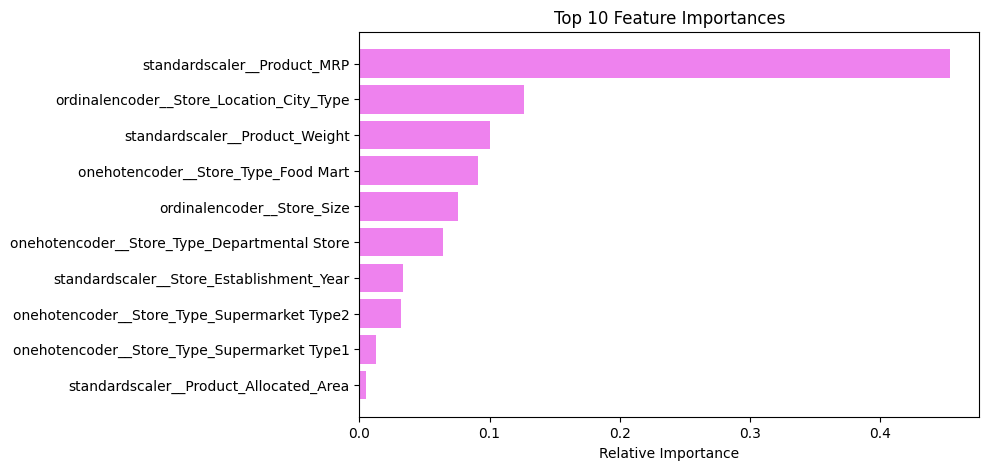

```python
# Plotting the top 10 feature importances of the model
feature_names = loaded_model.named_steps['columntransformer'].get_feature_names_out(input_features=X_train.columns)
importances = loaded_model.named_steps['randomforestregressor'].feature_importances_
indices = np.argsort(importances)
top_indices = indices[-10:]

plt.figure(figsize=(8, 5))
plt.title("Top 10 Feature Importances")
plt.barh(range(len(top_indices)), importances[top_indices], color="violet", align="center")
plt.yticks(range(len(top_indices)), [feature_names[i] for i in top_indices])
plt.xlabel("Relative Importance")
plt.show()
```

```python
# Turn store_features into a dataframe
store_features_df = pd.DataFrame.from_dict(store_features, orient='index')
store_features_df.T
```

|  | OUT001 | OUT002 | OUT003 | OUT004 |
| --- | --- | --- | --- | --- |
| Store_Establishment_Year | 1987 | 1998 | 1999 | 2009 |
| Store_Size | High | Small | Medium | Medium |
| Store_Location_City_Type | Tier 2 | Tier 3 | Tier 1 | Tier 2 |
| Store_Type | Supermarket Type1 | Food Mart | Departmental Store | Supermarket Type2 |

**Key Drivers of Sales Revenue**

Feature importance analysis from the model identified the following as the top three predictors of sales performance:

1. Product MRP:
   - Higher-priced or premium items are major contributors to revenue, suggesting strong customer segments for higher-end products.
2. Store Location City Type:
   - Tier 1 cities drive substantially higher revenue, likely due to stronger purchasing power and wider product variety.
3. Product Weight:
   - Heavier items (e.g., bulk goods, large packages) tend to generate higher total sales per product-store pairing.

Recommendation:

- Increase marketing and inventory allocation toward premium, higher-MRP products, especially in Tier 1 and Tier 2 cities.
- Re-evaluate product mix in Tier 3 cities, where lighter, lower-priced goods may perform better.
- Use these insights to inform dynamic pricing and store-level assortment optimization strategies.

**Regional & Store-Level Forecasting**

The model's high accuracy allows for store-level and city-tier forecasting, providing operational clarity across SuperKarts regional divisions.

Business Actions:

- Regional Managers can use forecasts to set realistic quarterly sales targets.
- Identify high-growth regions for expansion or product diversification.
- Detect underperforming stores early and deploy targeted marketing or local promotions.

Recommendation:

- Deploy the model outputs into an internal dashboard to visualize predicted vs. actual sales by store, product category, and city tier.

**Strategic and Financial Planning**

Forecasting future sales revenue at this accuracy level enables better coordination across departments:

- Finance: Improved revenue projections for budgeting and capital allocation.
- Marketing: Smarter timing of campaigns based on predicted sales surges.
- Operations: Proactive workforce planning for high-demand periods.

Recommendation:

- Establish quarterly forecast reviews between Finance, Marketing, and Operations to align planning cycles with model outputs.

**Deployment Architecture: Flexibility, Scalability, and Reusability**

The SuperKart forecasting system was deployed using a **modular architecture** with a Flask-based backend and a Streamlit-based frontend, both hosted on Hugging Face Spaces, enabling single or batch prediction.

- This **decoupled design** allows each component to be updated or scaled independently—new model versions can be deployed without changing the interface, and the backend can handle increased traffic without affecting user performance.

The architecture is **technology-agnostic**, meaning SuperKart can easily adopt alternative frameworks (e.g., FastAPI or React) as needs evolve. Additionally, the **backend API is reusable**, allowing seamless integration with other internal systems such as inventory management, analytics dashboards, or regional sales tools.

- This makes the solution **flexible, maintainable, and enterprise-ready**—a scalable foundation for future AI-driven decision systems.

**Model Monitoring and Continuous Improvement**

To maintain forecast accuracy over time, the model should be **monitored and retrained regularly** as sales trends, pricing, or consumer behavior evolve.

- Key metrics such as **R²** should be tracked continuously to detect performance drift across stores or product categories.

A **quarterly retraining cycle** using updated sales data will help the model adapt to changing market dynamics.

- Because the backend is modular, new model versions can be deployed seamlessly without interrupting frontend operations.

This approach ensures the forecasting system remains **accurate, reliable, and aligned with SuperKart's evolving business environment**, supporting consistent, data-driven decision-making across the organization.